# Investigating the Association Between Maternal Folic Acid Supplementation During Pregnancy and the Risk of Low Birth Weight

BMIN503/EPID600 Final Project

Author

Michaela Olabisi

## 1 Overview

This study examines the link between maternal folic acid supplementation before and during pregnancy and the risk of delivering a low birth weight (LBW) infant, defined as a birth weight below 2,500 grams.<sup>1</sup> LBW is associated with higher neonatal morbidity and long-term health issues. Folic acid, vital for fetal development, may help prevent LBW by supporting placental health. Using data from the Pregnancy Risk Assessment Monitoring System (PRAMS), the study finds that folic acid supplementation during pregnancy appears to reduce LBW risk, while pre-pregnancy intake may slightly increase it. Socioeconomic factors, such as education and income, as well as race and prenatal care, also play significant roles in LBW outcomes. The study highlights the need for targeted interventions addressing these factors to reduce LBW rates. I consulted with Dr. John Holmes and Dr. Ellen Caniglia from the Department of Biostatistics, Epidemiology & Informatics. Dr. Holmes highlighted potential study limitations, such as selection bias, while Dr. Caniglia shared a relevant [paper](https://pubmed.ncbi.nlm.nih.gov/35561720/) that examines the link between supplementation and adverse pregnancy outcomes like preterm birth (PTB) and LBW. You can access the final project, including all code and results, on my GitHub: https://github.com/msaolabisi/BMIN503_Final_Project.git

## 2 Introduction

The problem I’m addressing in this project is the potential link between maternal folic acid supplementation before and during pregnancy and the risk of delivering a LBW infant, defined as a birth weight under 2,500 grams. LBW is an important indicator of adverse pregnancy outcomes, including higher rates of neonatal morbidity, mortality, and long-term developmental issues like cardiovascular and metabolic disorders.<sup>2</sup> These conditions put a lot of stress on healthcare systems, driving up costs and the need for more intensive care, including extended stays in the NICU (Neonatal Intensive Care Unit).<sup>3</sup> It’s important to identify maternal factors that can be changed to lower the risk of LBW, as this could help improve the health of both mothers and babies.

Folic acid is a B vitamin that’s often recommended during pregnancy to help prevent birth defects like spina bifida.<sup>4</sup> It helps with DNA production, cell growth, and tissue development, which are all crucial for the rapid development of the fetus.<sup>5</sup> Folic acid may also support the placenta, which provides the fetus with nutrients and oxygen, and a healthy placenta can help prevent LBW.<sup>5</sup> By reducing these issues, folic acid might help lower the chances of having an LBW baby.

Despite these potential benefits, the direct relationship between folic acid and LBW isn’t fully established, and the research results are inconsistent. This is why it’s important to further investigate how folic acid supplementation before and during pregnancy might affect LBW.

This issue spans multiple fields. Epidemiology helps us understand the patterns and causes of LBW, while biostatistics is used to analyze large datasets like PRAMS. Public health looks at how factors like folic acid impact maternal and fetal health at the population level. Nutrition explains the role of folic acid in fetal development, and obstetrics and maternal health offer insights into how maternal health, prenatal care, and pregnancy complications influence birth weight outcomes.

When I spoke with Dr. John Holmes and Dr. Ellen Caniglia from the Department of Biostatistics, Epidemiology & Informatics, they helped me better understand the challenges of studying this issue. Dr. Holmes stressed the importance of addressing biases, like selection bias, when interpreting data in this case and Dr. Caniglia shared her research on supplementation and pregnancy outcomes, providing valuable context for studying the link between folic acid and LBW.

By drawing from these different fields of expertise, this project seeks to clarify the potential role of folic acid supplementation in reducing LBW.

## 3 Methods

The PRAMS survey included a core set of questions and optional standard questions tailored to state-specific needs. For this study, the primary exposure variables were folic acid supplementation before and during pregnancy, both categorized as “Yes” or “No.” The primary outcome was infant birth weight, categorized as “Yes Low Birth Weight” or “No Low Birth Weight” Covariates included maternal age, race/ethnicity, education, smoking during pregnancy, pre-pregnancy BMI, prenatal care utilization, state, and income.

Descriptive statistics were used to summarize maternal and infant characteristics, stratified by LBW status, and analyzed using t-tests for continuous variables and chi-square tests for categorical variables. Univariate and multivariate logistic regression models were employed to estimate unadjusted and adjusted odds ratios (aORs) for the relationship between folic acid intake (before and during pregnancy) and LBW, adjusting for covariates. Additional tables and figures included 2x2 tables to assess the relationship between exposures and outcome, bar plots displaying the relationship between exposures, covariates, and LBW, and a dot plot showing LBW counts across states. A forest plot was also generated to display both adjusted and unadjusted odds ratios (ORs) for the association between folic acid intake (before and during pregnancy) and LBW.

## 4 Install, Read, & Load Packages {#sec-install-read-&-load-packages}

```r
options(repos = c(CRAN = "https://cloud.r-project.org"))

##install packages
install.packages("haven")
install.packages("tableone")
install.packages("viridis")
install.packages("sf")
install.packages("maps")
install.packages("gt")
##load packages
library(gt)
library(haven)
library(dplyr)
library(tidyr)
library(ggplot2)
library(caret)
library(boot)
library(tableone)
library(broom)
library(viridis)
library(sf)
library(maps)
```

```r
# read a .sas7bdat file
data <- read_sas("/Users/molabisi/Downloads/PRAMS ARF/phase8_arf_2016_2022.sas7bdat")

# view the first few rows of the data
head(data)
```

```
# A tibble: 6 × 486
  ID           STATE HISPANIC MODECONT PARTICIP MODE_PRT MM_DOB B_ORDER BRSTFED
  <chr>        <chr>    <dbl>    <dbl>    <dbl>    <dbl>  <dbl>   <dbl>   <dbl>
1 2016AK327002 AK           1        2        1        2     NA       1       2
2 2016AK327006 AK           1        2        1        2     NA       1       1
3 2016AK327007 AK           1        1        1        1     NA       1       1
4 2016AK327009 AK           1        2        1        2     NA       1       1
5 2016AK327010 AK           1        2        1        2     NA       1       1
6 2016AK327011 AK           1        2        1        2     NA       1       1
# ℹ 477 more variables: CIG_1TRI <dbl>, CIG_2TRI <dbl>, CIG_3TRI <dbl>,
#   CIG_PRIOR <dbl>, DEFECT <dbl>, DEL_1CS <dbl>, DEL_FORC <dbl>,
#   DEL_RCS <dbl>, DEL_VACM <dbl>, DEL_VAG <dbl>, DEL_VCS <dbl>,
#   FHISP_BC <dbl>, FRACE_AMI <dbl>, FRACE_BLK <dbl>, FRACE_WHT <dbl>,
#   HISP_BC <dbl>, INFER_TR <dbl>, MARRIED <dbl>, MAT_DEG <dbl>, MAT_ED <dbl>,
#   MAT_HTFT <dbl>, MAT_HTIN <dbl>, MAT_PRWT <dbl>, MAT_TRAN <dbl>,
#   MAT_WIC <dbl>, MM_DIAB <dbl>, MM_FEVER <dbl>, MM_HBP <dbl>, MM_LMP <dbl>, …
```

## 5 Cleaning Data

```r
## count/how many people in data set
cat("Total rows in the dataset:", nrow(data), "\n")
```

```
Total rows in the dataset: 249970
```

```r
##cleaning data
data_clean <- data %>%
##recoding exposure variables
  mutate(
     # For PRE_VIT_RAW (pre preg -- PPV -- folic acid)
    PRE_VIT_RAW = case_when(
      PRE_VIT_RAW == 1 ~ 0,   # NO -> 0
      PRE_VIT_RAW == 2 ~ 1,   # YES -> 1
      TRUE ~ NA_real_ # Keep other values unchanged
    ),
    # For VPP_VIT_RAW (during preg -- PPV -- folic acid)
    VPP_VIT_RAW = case_when(
      VPP_VIT_RAW == 1 ~ 0,   # NO -> 0
      VPP_VIT_RAW == 2 ~ 1,   # YES -> 1
      TRUE ~ NA_real_ # Keep other values unchanged
    ),

    # Convert to factors after recoding
    PRE_VIT_RAW = factor(PRE_VIT_RAW, levels = c(0, 1)),
    VPP_VIT_RAW = factor(VPP_VIT_RAW, levels = c(0, 1))
  )

## recoding outcome variables 4 categories
data_clean <- data_clean %>%
  mutate(
  GRAM_NAPHSIS = case_when(
    GRAM_NAPHSIS < 1500 ~ 0,       # VLBW: Less than 1500 grams
    GRAM_NAPHSIS >= 1500 & GRAM_NAPHSIS < 2500 ~ 1, # LBW: 1500-2499 grams
    GRAM_NAPHSIS >= 2500 & GRAM_NAPHSIS <= 4000 ~ 2, # NBW: 2500-4000 grams
    GRAM_NAPHSIS > 4000 ~ 3,       # Macrosomia: Over 4000 grams
    TRUE ~ NA_real_                # Missing or invalid data
  ),
  GRAM_NAPHSIS = factor(GRAM_NAPHSIS, levels = c(0, 1, 2, 3)),

## recoding outcome variable dichotomous
 LBW = case_when(
      GRAM_NAPHSIS == 0 | GRAM_NAPHSIS == 1 ~ 1,  # VLBW or LBW
      GRAM_NAPHSIS == 2 | GRAM_NAPHSIS == 3 ~ 0,   # NBW or Macrosomia
      TRUE ~ NA_real_ # Missing or invalid data
    ),
LBW = factor(LBW, levels = c(0, 1)),
  )
table(data_clean$PRE_VIT_RAW)
```

```
     0      1
110466  62669
```

```r
table(data_clean$VPP_VIT_RAW)
```

```
     0      1
 96628 121177
```

```r
table(data_clean$GRAM_NAPHSIS)
```

```
     0      1      2      3
  8491  44367 180131  16702
```

```r
table(data_clean$LBW)
```

```
     0      1
196833  52858
```

```r
## cleaning data
data_clean <- data_clean %>%
##cleaning covariates
  mutate(
    # Maternal Age
    MAT_AGE_PU = as.numeric(MAT_AGE_PU),

    # Parity
    PRE_LB_NAPHSIS = case_when(
      PRE_LB_NAPHSIS == 0 ~ 0,       # No children (0)
      PRE_LB_NAPHSIS == 1 ~ 1,       # One child (1)
      PRE_LB_NAPHSIS %in% c(2, 3, 4) ~ 2, # 2+ children (Yes, multiple)
      TRUE ~ NA_real_
    ),
    PRE_LB_NAPHSIS = as.factor(PRE_LB_NAPHSIS),

    # BMI
    MOM_BMI = as.numeric(MOM_BMI),

   # Education
    MAT_ED = case_when(
      MAT_ED %in% c(1, 2) ~ "<= 12th grade, no diploma",
      MAT_ED == 3 ~ "High school graduate / GED",
      MAT_ED == 4 ~ "Some college, no degree",
      MAT_ED == 5 ~ "Bachelor's, Master's, or higher",
      TRUE ~ NA_character_
    ),
    MAT_ED = as.factor(MAT_ED),

    # Income
  INCOME8 = case_when(
  INCOME8 %in% c(1, 2, 3, 4, 5, 6, 13, 14, 101, 102, 103, 104, 105) ~ "Low income (0 - $40,000)",
  INCOME8 %in% c(7, 8, 9, 10, 11, 106, 107, 108, 109) ~ "Middle ($40,001 - $85,000)",
  INCOME8 %in% c(12, 15, 16, 17, 18, 19, 20, 21, 22, 110, 111, 112) ~ "High income ($85,001 or more)",
  TRUE ~ NA_character_
),
  INCOME8 = as.factor(INCOME8),

  STATE = as.factor(STATE),

  PNC_VST = as.factor(PNC_VST),

  MAT_RACE_PU = case_when(
    MAT_RACE_PU == 2 ~ "White",
    MAT_RACE_PU == 3 ~ "Black",
    MAT_RACE_PU == 4 ~ "American Indian",
    MAT_RACE_PU == 10 ~ "Alaska Native",
    MAT_RACE_PU == 21 ~ "Asian",
    MAT_RACE_PU == 22 ~ "Hawaiian/Other Pacific Islander",
    MAT_RACE_PU == 23 ~ "Other/Multiple Race",
    TRUE ~ NA_character_
  ),
  MAT_RACE_PU = as.factor(MAT_RACE_PU)
  )

table(data_clean$PRE_VIT_RAW)
```

```
     0      1
110466  62669
```

```r
table(data_clean$VPP_VIT_RAW)
```

```
     0      1
 96628 121177
```

```r
table(data_clean$GRAM_NAPHSIS)
```

```
     0      1      2      3
  8491  44367 180131  16702
```

```r
table(data_clean$MAT_AGE_PU)
```

```
   17    18    19    20    21    22    23    24    25    26    27    28    29
 2822  2903  4871  6291  7528  8549  9464 10531 11728 12747 13511 14748 15113
   30    31    32    33    34    35    36    37    38    39    40    41    42
15463 15462 14615 13416 12348 11007  9337  7351  5779  4375  3147  2181  1429
   43    44    45
  808   444   607
```

```r
table(data_clean$PRE_LB_NAPHSIS)
```

```
    0     1     2
98325 78077 73021
```

```r
table(data_clean$MOM_BMI)
```

[output not shown]

[output cut: 3703 more lines]

[output not shown]

```r
table(data_clean$MAT_ED)
```

```
      <= 12th grade, no diploma Bachelor's, Master's, or higher
                          29383                           88853
     High school graduate / GED         Some college, no degree
                          59994                           69420
```

```r
table(data_clean$STATE)
```

```
   AK    AL    AR    AZ    CO    DC    DE    GA    HI    IA    IL    IN    KS
 5338  4602  4546  1640  8520  2554  6166  3993  5619  4436  7471   865  6339
   KY    LA    MA    MD    ME    MI    MN    MO    MP    MS    MT    ND    NE
 3940  5081 10115  5217  5712 11077  3597  7347   216  4371  5331  4107  8172
   NH    NJ    NM    NY    OR    PA    PR    RI    SD    TN    UT    VA    VT
 3039  7888  7818  5064  7627  7844  5830  5118  6419  1929  9824  6759  6047
   WA    WI    WV    WY    YC
 8344  7807  3389  3515  9337
```

```r
table(data_clean$INCOME8)
```

```
High income ($85,001 or more)      Low income (0 - $40,000)
                        60973                        107957
   Middle ($40,001 - $85,000)
                        53080
```

```r
table(data_clean$PNC_VST)
```

```
    0     1     2     3     4     5     6     7     8     9    10    11    12
 3504  1253  2039  2846  4105  5992  8130 10222 15324 18055 32468 27039 36332
   13    14    15    16    17    18    19    20    21    22    23    24    25
23637 17898 12546  6572  3795  2877  1679  2350   858   670   477   387   413
   26    27    28    29    30    31    32    33    34    35    36    37    38
  203   154   153    89   226    39    52    40    32    40    32    24    25
   39    40    41    42    43    44    45    46    47    48    49    50    51
   30    60    12     7     5     2     3     3     5     5     8    10     1
   53    54    56    58    60    64    66    88    90    94
    1     1     1     3     4     1     1     1     1     1
```

```r
table(data_clean$MAT_RACE_PU)
```

```
                American Indian                           Asian
                           8693                           16210
                          Black Hawaiian/Other Pacific Islander
                          43561                            1326
            Other/Multiple Race                           White
                          25898                          140667
```

## 6 Results

## 7 Descriptive Statistics

```r
#specifying continuous and categorical variables
# List of continuous variables
cont_vars <- c("MAT_AGE_PU", "MOM_BMI")

# List of categorical variables
cat_vars <- c("PRE_VIT_RAW", "VPP_VIT_RAW", "GRAM_NAPHSIS", "LBW", "PRE_LB_NAPHSIS", "MAT_ED", "STATE", "INCOME8", "PNC_VST", "MAT_RACE_PU")
```

### 7.1 Descriptive Table - ALL

```r
# descriptive tables
table1 <- CreateTableOne(vars = c(cont_vars, cat_vars), data = data_clean)
print(table1, showAllLevels = TRUE)
```

```
                         level                           Overall
  n                                                      249970
  MAT_AGE_PU (mean (SD))                                  29.30 (5.76)
  MOM_BMI (mean (SD))                                     27.11 (6.89)
  PRE_VIT_RAW (%)        0                               110466 (63.8)
                         1                                62669 (36.2)
  VPP_VIT_RAW (%)        0                                96628 (44.4)
                         1                               121177 (55.6)
  GRAM_NAPHSIS (%)       0                                 8491 ( 3.4)
                         1                                44367 (17.8)
                         2                               180131 (72.1)
                         3                                16702 ( 6.7)
  LBW (%)                0                               196833 (78.8)
                         1                                52858 (21.2)
  PRE_LB_NAPHSIS (%)     0                                98325 (39.4)
                         1                                78077 (31.3)
                         2                                73021 (29.3)
  MAT_ED (%)             <= 12th grade, no diploma        29383 (11.9)
                         Bachelor's, Master's, or higher  88853 (35.9)
                         High school graduate / GED       59994 (24.2)
                         Some college, no degree          69420 (28.0)
  STATE (%)              AK                                5338 ( 2.1)
                         AL                                4602 ( 1.8)
                         AR                                4546 ( 1.8)
                         AZ                                1640 ( 0.7)
                         CO                                8520 ( 3.4)
                         DC                                2554 ( 1.0)
                         DE                                6166 ( 2.5)
                         GA                                3993 ( 1.6)
                         HI                                5619 ( 2.2)
                         IA                                4436 ( 1.8)
                         IL                                7471 ( 3.0)
                         IN                                 865 ( 0.3)
                         KS                                6339 ( 2.5)
                         KY                                3940 ( 1.6)
                         LA                                5081 ( 2.0)
                         MA                               10115 ( 4.0)
                         MD                                5217 ( 2.1)
                         ME                                5712 ( 2.3)
                         MI                               11077 ( 4.4)
```

[output cut: 81 more lines]

```
                         54                                   1 ( 0.0)
                         56                                   1 ( 0.0)
                         58                                   3 ( 0.0)
                         60                                   4 ( 0.0)
                         64                                   1 ( 0.0)
                         66                                   1 ( 0.0)
                         88                                   1 ( 0.0)
                         90                                   1 ( 0.0)
                         94                                   1 ( 0.0)
  MAT_RACE_PU (%)        American Indian                   8693 ( 3.7)
                         Asian                            16210 ( 6.9)
                         Black                            43561 (18.4)
                         Hawaiian/Other Pacific Islander   1326 ( 0.6)
                         Other/Multiple Race              25898 (11.0)
                         White                           140667 (59.5)
```

```r
#summary(table1, showAllLevels = TRUE)
```

### 7.2 Descriptive Table - vlbw, lbw, nbw, mac

```r
#specifying continuous and categorical variables
# List of continuous variables
cont_vars1 <- c("MAT_AGE_PU", "MOM_BMI")

# List of categorical variables
cat_vars1 <- c("PRE_VIT_RAW", "VPP_VIT_RAW", "PRE_LB_NAPHSIS", "MAT_ED", "STATE", "INCOME8", "PNC_VST", "MAT_RACE_PU")
```

```r
## cleaning data
data_clean_filtered <- data_clean %>%
  filter(complete.cases(select(., c(cont_vars1, cat_vars1))))
# Variables to include in the descriptive table - lbw, vlbw, nbw, mac
# Create stratified descriptive table
table2 <- CreateTableOne(vars = c(cont_vars1, cat_vars1), strata = "GRAM_NAPHSIS", data = data_clean)
print(table2, showAllLevels = TRUE)
```

```
                        Stratified by GRAM_NAPHSIS
                         level                           0
  n                                                       8491
  MAT_AGE_PU (mean (SD))                                 29.46 (6.13)
  MOM_BMI (mean (SD))                                    28.67 (7.63)
  PRE_VIT_RAW (%)        0                                3785 (62.1)
                         1                                2313 (37.9)
  VPP_VIT_RAW (%)        0                                3349 (45.9)
                         1                                3955 (54.1)
  PRE_LB_NAPHSIS (%)     0                                4079 (48.3)
                         1                                2146 (25.4)
                         2                                2222 (26.3)
  MAT_ED (%)             <= 12th grade, no diploma        1014 (12.1)
                         Bachelor's, Master's, or higher  2444 (29.2)
                         High school graduate / GED       2371 (28.3)
```

[output cut: 247 more lines]

```r
# summary(table2)
```

There is a significant difference in maternal age, BMI, pre-pregnancy folic intake, pregnancy folic intake, parity, maternal education, state, income, prenatal care visit count, and race between the different categories of birth weight (very low birth weight, low birth weight, normal birth weight, and macrasomia).

### 7.3 Descriptive Table - yes lbw, no lbw

```r
# Variables to include in the descriptive table - lbw, not lbw
# Create stratified descriptive table
table3 <- CreateTableOne(vars = c(cont_vars1, cat_vars1), strata = "LBW", data = data_clean)
print(table3, showAllLevels = TRUE)
```

```
                        Stratified by LBW
                         level                           0
  n                                                      196833
  MAT_AGE_PU (mean (SD))                                  29.30 (5.68)
  MOM_BMI (mean (SD))                                     27.11 (6.78)
  PRE_VIT_RAW (%)        0                                86960 (64.1)
                         1                                48759 (35.9)
  VPP_VIT_RAW (%)        0                                75658 (43.9)
                         1                                96560 (56.1)
  PRE_LB_NAPHSIS (%)     0                                74802 (38.1)
                         1                                63587 (32.4)
                         2                                58086 (29.6)
  MAT_ED (%)             <= 12th grade, no diploma        22661 (11.6)
                         Bachelor's, Master's, or higher  72454 (37.1)
                         High school graduate / GED       45809 (23.5)
```

[output cut: 247 more lines]

```r
#summary(table3)
```

There is a significant difference in pre-pregnancy folic intake, pregnancy folic intake, parity, maternal education, state, income, prenatal care visit count, and race between low birth weight.

## 8 2x2 Tables

```r
# 2x2 tables
addmargins(table(data_clean$PRE_VIT_RAW, data_clean$LBW,
                 dnn = c("Pre-pregnancy Folic Intake",
                         "LBW")))
```

```
                          LBW
Pre-pregnancy Folic Intake      0      1    Sum
                       0    86960  23368 110328
                       1    48759  13835  62594
                       Sum 135719  37203 172922
```

```r
addmargins(table(data_clean$VPP_VIT_RAW, data_clean$LBW,
                 dnn = c("Pre-pregnancy Folic Intake",
                         "LBW")))
```

```
                          LBW
Pre-pregnancy Folic Intake      0      1    Sum
                       0    75658  20846  96504
                       1    96560  24515 121075
                       Sum 172218  45361 217579
```

For Pre-pregnancy- 86960 individuals who did not have low birth weight and did not have pre-pregnancy folic intake. 23368 individuals who had low birth weight and did not have pre-pregnancy folic intake. 48759 individuals who did not have low birth weight and had pre-pregnancy folic intake. 13835 individuals who had low birth weight and had pre-pregnancy folic intake.

For pregnancy- 75658 individuals who did not have low birth weight and did not have folic intake during pregnancy. 20846 individuals who had low birth weight and did not have folic intake during pregnancy. 96560 individuals who did not have low birth weight and have folic intake during pregnancy. 24515 individuals who had low birth weight and have folic intake during pregnancy.

```r
# For PRE_VIT_RAW vs. LBW
chisq.test(table(data_clean$PRE_VIT_RAW, data_clean$LBW))
```

```
    Pearson's Chi-squared test with Yates' continuity correction

data:  table(data_clean$PRE_VIT_RAW, data_clean$LBW)
X-squared = 20.063, df = 1, p-value = 7.494e-06
```

```r
# For VPP_VIT_RAW vs. LBW
chisq.test(table(data_clean$VPP_VIT_RAW, data_clean$LBW))
```

```
    Pearson's Chi-squared test with Yates' continuity correction

data:  table(data_clean$VPP_VIT_RAW, data_clean$LBW)
X-squared = 59.526, df = 1, p-value = 1.207e-14
```

Both pre-pregnancy folic intake and folic intake supplementation during pregnancy appear to be significantly associated with low birth weight. These findings suggest that maternal folic intake, either before or during pregnancy, could play an important role in birth weight outcomes.

## 9 Bar Plots

### 9.1 Count of People with Folic Acid Intake (Pre and During Pregnancy Bar Plots)

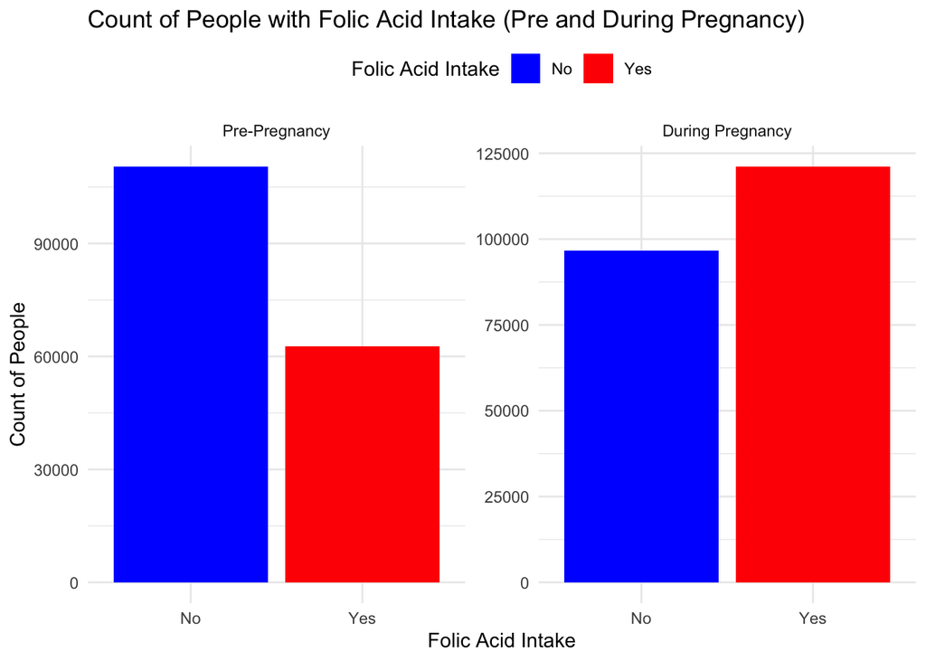

```r
# Combine both Pre and During Pregnancy Folic Acid Intake Counts in One Plot
data_clean %>%
  gather(key = "Pregnancy_Status", value = "Folic_Acid_Intake", PRE_VIT_RAW, VPP_VIT_RAW) %>%
  mutate(Folic_Acid_Intake = factor(Folic_Acid_Intake, levels = c(0, 1), labels = c("No", "Yes"))) %>%
  filter(!is.na(Folic_Acid_Intake)) %>%
  ggplot(aes(x = Folic_Acid_Intake, fill = Folic_Acid_Intake)) +
  geom_bar() +
  scale_fill_manual(values = c("blue", "red")) +
  facet_wrap(~ Pregnancy_Status, scales = "free", labeller = labeller(Pregnancy_Status = c("PRE_VIT_RAW" = "Pre-Pregnancy", "VPP_VIT_RAW" = "During Pregnancy"))) +
  labs(x = "Folic Acid Intake", y = "Count of People", fill = "Folic Acid Intake",
       title = "Count of People with Folic Acid Intake (Pre and During Pregnancy)") +
  theme_minimal() +
  theme(legend.position = "top")
```

```r
# Count people by folic acid intake status for both pre-pregnancy and during pregnancy
data_clean %>%
  gather(key = "Pregnancy_Status", value = "Folic_Acid_Intake", PRE_VIT_RAW, VPP_VIT_RAW) %>%
  mutate(Folic_Acid_Intake = factor(Folic_Acid_Intake, levels = c(0, 1), labels = c("No", "Yes"))) %>%
  filter(!is.na(Folic_Acid_Intake)) %>%
  count(Pregnancy_Status, Folic_Acid_Intake)
```

```
# A tibble: 4 × 3
  Pregnancy_Status Folic_Acid_Intake      n
  <chr>            <fct>              <int>
1 PRE_VIT_RAW      No                110466
2 PRE_VIT_RAW      Yes                62669
3 VPP_VIT_RAW      No                 96628
4 VPP_VIT_RAW      Yes               121177
```

A larger proportion of people took folic acid during pregnancy (121,177 people) compared to before pregnancy (62,669 people). Similarly, more people did not take folic acid before pregnancy (110,466 people) than during pregnancy (96,628 people).

### 9.2 Pre-Pregnancy Folic Acid Intake Bar Plots

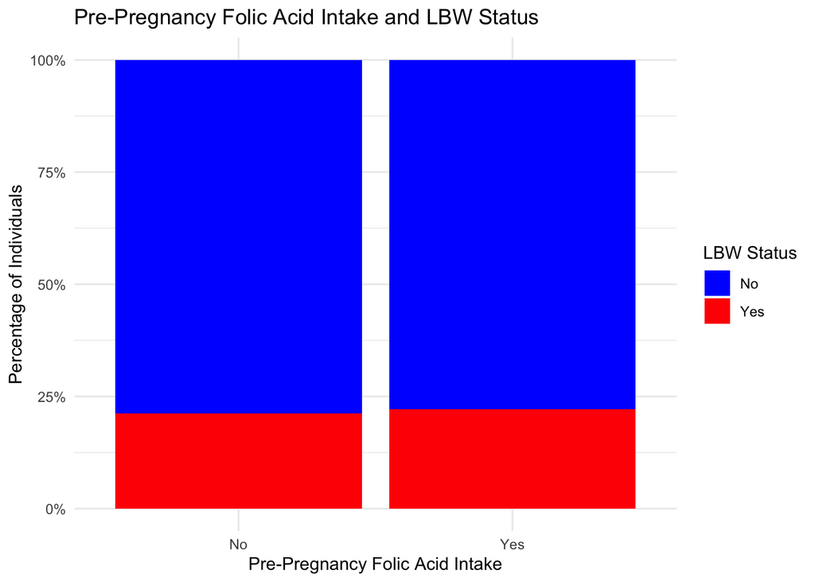

```r
## barplot of Pre-Pregnancy Folic Acid Intake and LBW Status
ggplot(data_clean %>% filter(!is.na(PRE_VIT_RAW), !is.na(LBW)), aes(x = PRE_VIT_RAW, fill = factor(LBW))) +
  geom_bar(position = "fill") +  # "fill" makes the bars proportional (percentage)
  scale_y_continuous(labels = scales::percent) +
  scale_x_discrete(labels = c("0" = "No", "1" = "Yes")) +  # Change 0, 1 to No, Yes on x-axis
  scale_fill_manual(values = c("0" = "blue", "1" = "red"), labels = c("0" = "No", "1" = "Yes")) +  # Change 0, 1 to No, Yes in the legend
  labs(x = "Pre-Pregnancy Folic Acid Intake", y = "Percentage of Individuals", fill = "LBW Status",
       title = "Pre-Pregnancy Folic Acid Intake and LBW Status") +
  theme_minimal()
```

```r
data_clean %>%
  filter(!is.na(PRE_VIT_RAW), !is.na(LBW)) %>%
  count(PRE_VIT_RAW, LBW)
```

```
# A tibble: 4 × 3
  PRE_VIT_RAW LBW       n
  <fct>       <fct> <int>
1 0           0     86960
2 0           1     23368
3 1           0     48759
4 1           1     13835
```

Pre-pregnancy: For people with no folic acid intake: 78.8% do not have LBW 21.2% have LBW

For people with folic acid intake: 77.9% do not have LBW 22.1% have LBW

### 9.3 During Pregnancy Folic Acid Intake Bar Plots

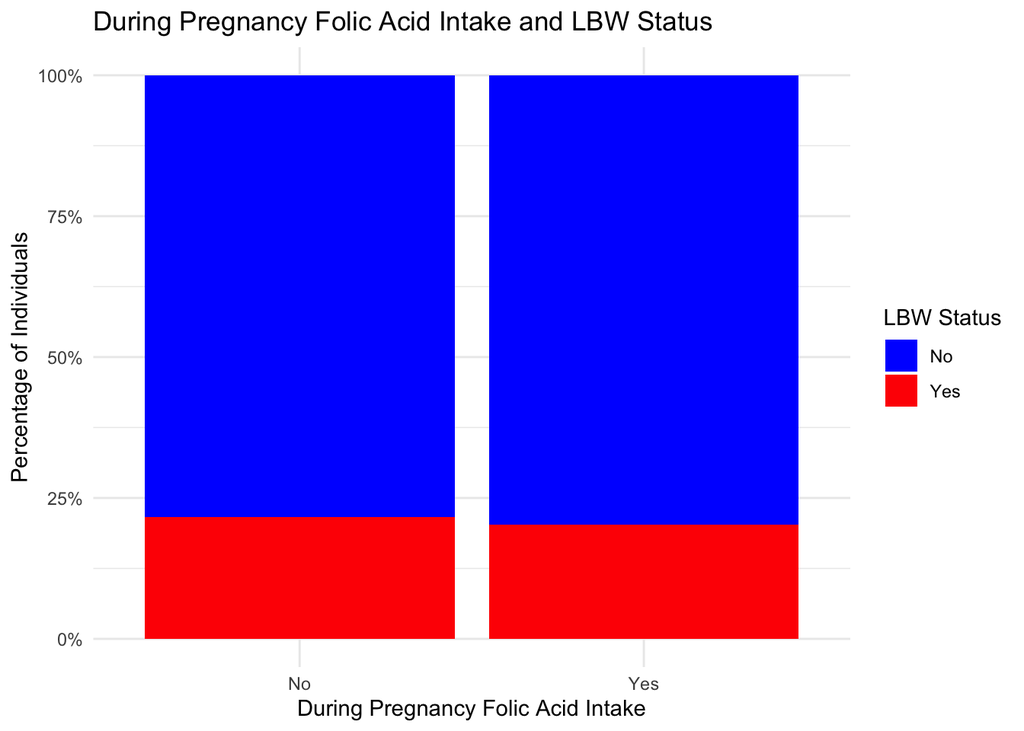

```r
## bar plot of During Pregnancy Folic Acid Intake Bar Plots
ggplot(data_clean %>% filter(!is.na(VPP_VIT_RAW), !is.na(LBW)), aes(x = VPP_VIT_RAW, fill = factor(LBW))) +
  geom_bar(position = "fill") +  # "fill" makes the bars proportional (percentage)
  scale_y_continuous(labels = scales::percent) +
  scale_x_discrete(labels = c("0" = "No", "1" = "Yes")) +  # Change 0, 1 to No, Yes on x-axis
  scale_fill_manual(values = c("0" = "blue", "1" = "red"), labels = c("0" = "No", "1" = "Yes")) +  # Change 0, 1 to No, Yes in the legend
  labs(x = "During Pregnancy Folic Acid Intake", y = "Percentage of Individuals", fill = "LBW Status",
       title = "During Pregnancy Folic Acid Intake and LBW Status") +
  theme_minimal()
```

```r
data_clean %>%
  filter(!is.na(VPP_VIT_RAW), !is.na(LBW)) %>%
  count(VPP_VIT_RAW, LBW)
```

```
# A tibble: 4 × 3
  VPP_VIT_RAW LBW       n
  <fct>       <fct> <int>
1 0           0     75658
2 0           1     20846
3 1           0     96560
4 1           1     24515
```

During pregnancy: For people with no folic acid intake during pregnancy: 78.4% do not have LBW 21.6% have LBW For people with folic acid intake during pregnancy: 79.8% do not have LBW 20.2% have LBW

### 9.4 Parity

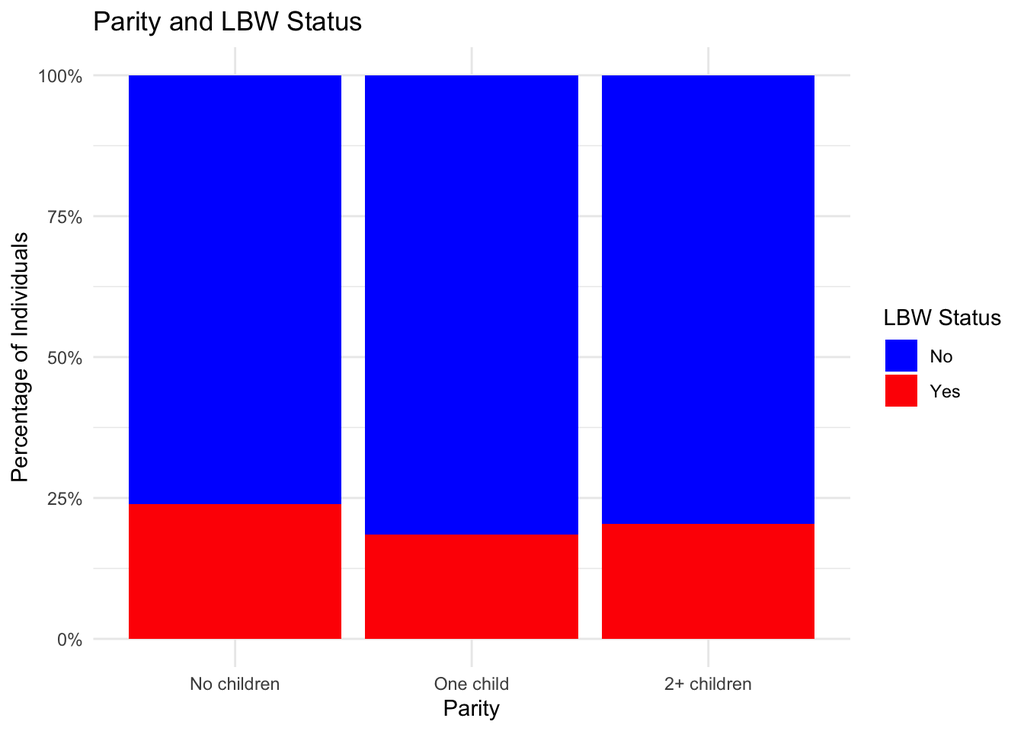

```r
##bar plot of Parity and LBW Status
ggplot(data_clean %>% filter(!is.na(PRE_LB_NAPHSIS), !is.na(LBW)), aes(x = PRE_LB_NAPHSIS, fill = factor(LBW))) +
  geom_bar(position = "fill") +  # "fill" makes the bars proportional (percentage)
  scale_y_continuous(labels = scales::percent) +
  scale_x_discrete(labels = c("0" = "No children", "1" = "One child", "2" = "2+ children")) +  # Change 0, 1 to No, Yes on x-axis
  scale_fill_manual(values = c("0" = "blue", "1" = "red"), labels = c("0" = "No", "1" = "Yes")) +  # Change 0, 1 to No, Yes in the legend
  labs(x = "Parity", y = "Percentage of Individuals", fill = "LBW Status",
       title = "Parity and LBW Status") +
  theme_minimal()
```

```r
data_clean %>%
  filter(!is.na(PRE_LB_NAPHSIS), !is.na(LBW)) %>%
  count(PRE_LB_NAPHSIS, LBW)
```

```
# A tibble: 6 × 3
  PRE_LB_NAPHSIS LBW       n
  <fct>          <fct> <int>
1 0              0     74802
2 0              1     23429
3 1              0     63587
4 1              1     14409
5 2              0     58086
6 2              1     14873
```

For PRE_LB_NAPHSIS = 0: 76.2% do not have LBW 23.8% have LBW

For PRE_LB_NAPHSIS = 1: 81.5% do not have LBW 18.5% have LBW

For PRE_LB_NAPHSIS = 2: 79.6% do not have LBW 20.4% have LBW

First-time pregnancies (PRE_LB_NAPHSIS = 0) are associated with the highest LBW risk (23.8%). One prior pregnancy (PRE_LB_NAPHSIS = 1) seems to have the best outcomes with the lowest proportion of LBW (18.5%). Multiple prior pregnancies (PRE_LB_NAPHSIS = 2) show an intermediate risk. These patterns suggest that maternal history of prior pregnancies influences birth weight outcomes, potentially due to biological or healthcare-related factors that improve with experience or repeated exposure to pregnancy.

### 9.5 Maternal Age

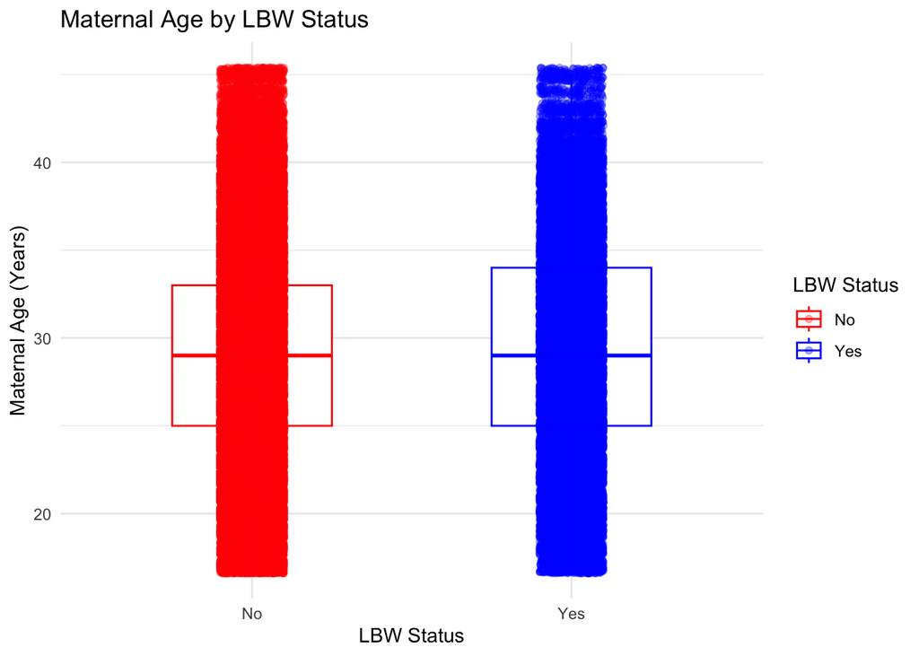

```r
## box plot of Maternal Age by LBW Status
data_clean %>%
  filter(!is.na(MAT_AGE_PU), !is.na(LBW)) %>%
  ggplot(aes(x = factor(LBW, levels = c("0", "1"), labels = c("No", "Yes")), y = MAT_AGE_PU, color = factor(LBW, levels = c("0", "1"), labels = c("No", "Yes")))) +
  geom_boxplot(width = 0.5) +
  geom_jitter(width = 0.1, alpha = 0.3) +
  ggtitle("Maternal Age by LBW Status") +
  xlab("LBW Status") +
  ylab("Maternal Age (Years)") +
  scale_color_manual(name = "LBW Status", values = c("red", "blue")) +
  theme_minimal()  # Use a built-in theme here
```

```r
ci_data <- data_clean %>%
  filter(!is.na(MAT_AGE_PU), !is.na(LBW)) %>%
  group_by(LBW) %>%
  summarize(
    Median_Age = median(MAT_AGE_PU),
    IQR_Lower = quantile(MAT_AGE_PU, 0.25),
    IQR_Upper = quantile(MAT_AGE_PU, 0.75)
  )

print(ci_data)
```

```
# A tibble: 2 × 4
  LBW   Median_Age IQR_Lower IQR_Upper
  <fct>      <dbl>     <dbl>     <dbl>
1 0             29        25        33
2 1             29        25        34
```

For individuals without LBW (LBW group 0), the central value of maternal age is 29 years, with the middle 50% of the ages falling between 25 and 33 years. For individuals with LBW (LBW group 1), the median maternal age is also 29 years. However, the range of ages for the middle 50% of individuals is slightly broader, spanning from 25 to 34 years.

### 9.6 Maternal BMI

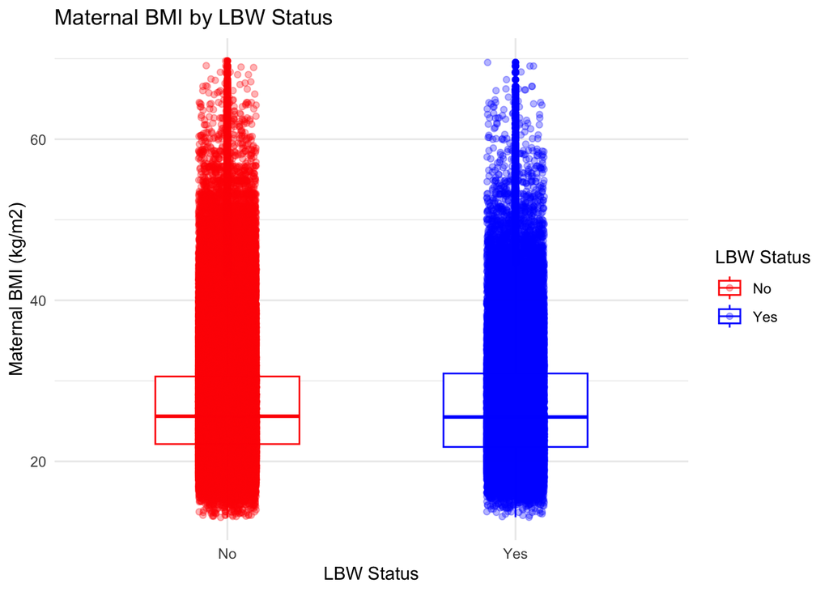

```r
## box plot of Maternal BMI by LBW Status
data_clean %>%
  filter(!is.na(MOM_BMI), !is.na(LBW)) %>%
  ggplot(aes(x = factor(LBW, levels = c("0", "1"), labels = c("No", "Yes")), y = MOM_BMI, color = factor(LBW, levels = c("0", "1"), labels = c("No", "Yes")))) +
  geom_boxplot(width = 0.5) +
  geom_jitter(width = 0.1, alpha = 0.3) +
  ggtitle("Maternal BMI by LBW Status") +
  xlab("LBW Status") +
  ylab("Maternal BMI (kg/m2)") +
  scale_color_manual(name = "LBW Status", values = c("red", "blue")) +
  theme_minimal()  # Use a built-in theme here
```

```r
ci_data <- data_clean %>%
  filter(!is.na(MOM_BMI), !is.na(LBW)) %>%
  group_by(LBW) %>%
  summarize(
    Median_Age = median(MOM_BMI),
    IQR_Lower = quantile(MOM_BMI, 0.25),
    IQR_Upper = quantile(MOM_BMI, 0.75)
  )

print(ci_data)
```

```
# A tibble: 2 × 4
  LBW   Median_Age IQR_Lower IQR_Upper
  <fct>      <dbl>     <dbl>     <dbl>
1 0           25.6      22.2      30.5
2 1           25.5      21.8      30.9
```

For mothers whose babies did not have low birth weight, the middle 50% of BMI range from 22.15 to 30.54 kg/m^2;, with a median of 25.61 kg/m^2. For mothers whose babies did have low birth weight, the middle 50% of BMI range from 21.79 to 30.91 kg/m^2, with a median of 25.51 kg/m^2.

### 9.7 Maternal Education

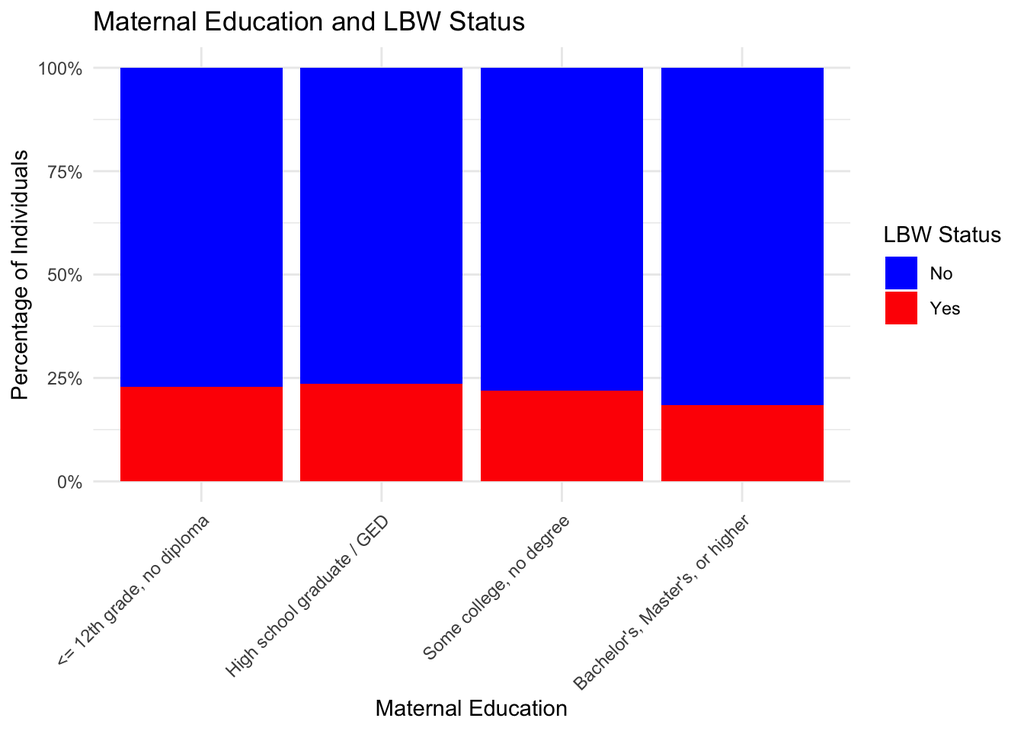

```r
## bar plot of Maternal Education and LBW Status
ggplot(data_clean %>%
         filter(!is.na(MAT_ED), !is.na(LBW)) %>%
         mutate(MAT_ED = factor(MAT_ED, levels = c("<= 12th grade, no diploma",
                                                   "High school graduate / GED",
                                                   "Some college, no degree",
                                                   "Bachelor's, Master's, or higher"))),
       aes(x = MAT_ED, fill = factor(LBW))) +
  geom_bar(position = "fill") +  # "fill" makes the bars proportional (percentage)
  scale_y_continuous(labels = scales::percent) +
  scale_fill_manual(values = c("0" = "blue", "1" = "red"), labels = c("0" = "No", "1" = "Yes")) +  # Custom colors for LBW
  labs(
    x = "Maternal Education",
    y = "Percentage of Individuals",
    fill = "LBW Status",
    title = "Maternal Education and LBW Status"
  ) +
  theme_minimal() +
  theme(axis.text.x = element_text(angle = 45, hjust = 1))
```

```r
data_clean %>%
  filter(!is.na(MAT_ED), !is.na(LBW)) %>%
  count(MAT_ED, LBW)
```

```
# A tibble: 8 × 3
  MAT_ED                          LBW       n
  <fct>                           <fct> <int>
1 <= 12th grade, no diploma       0     22661
2 <= 12th grade, no diploma       1      6694
3 Bachelor's, Master's, or higher 0     72454
4 Bachelor's, Master's, or higher 1     16296
5 High school graduate / GED      0     45809
6 High school graduate / GED      1     14139
7 Some college, no degree         0     54181
8 Some college, no degree         1     15179
```

<= 12th grade, no diploma: No LBW: 77.2% of individuals without a diploma had babies with normal birth weight. LBW: 22.8% of individuals without a diploma had babies with low birth weight.

High school graduate / GED: No LBW: 76.4% of high school graduates had babies with normal birth weight. LBW: 23.6% of high school graduates had babies with low birth weight.

Some college, no degree: No LBW: 78.1% of individuals with some college education had babies with normal birth weight. LBW: 21.9% of individuals with some college education had babies with low birth weight.

Bachelor’s, Master’s, or higher: No LBW: 81.6% of individuals with higher education had babies with normal birth weight. LBW: 18.4% of individuals with higher education had babies with low birth weight.

Higher maternal education is associated with a lower proportion of low birth weight outcomes.

### 9.8 Income

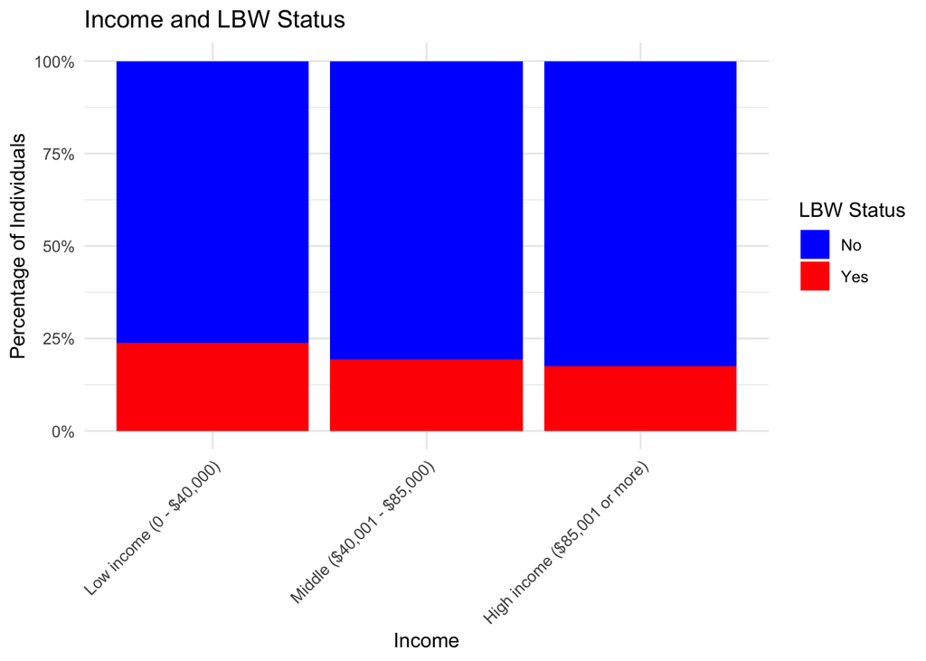

```r
ggplot(data_clean %>%
         filter(!is.na(INCOME8), !is.na(LBW)) %>%
         mutate(INCOME8 = factor(INCOME8, levels = c("Low income (0 - $40,000)",
                                                     "Middle ($40,001 - $85,000)",
                                                     "High income ($85,001 or more)"))),
       aes(x = INCOME8, fill = factor(LBW))) +
  geom_bar(position = "fill") +  # "fill" makes the bars proportional (percentage)
  scale_y_continuous(labels = scales::percent) +
  scale_fill_manual(values = c("0" = "blue", "1" = "red"), labels = c("0" = "No", "1" = "Yes")) +  # Change 0, 1 to No, Yes in the legend
  labs(x = "Income", y = "Percentage of Individuals", fill = "LBW Status",
       title = "Income and LBW Status") +
  theme_minimal() +
  theme(axis.text.x = element_text(angle = 45, hjust = 1))
```

```r
data_clean %>%
  filter(!is.na(INCOME8), !is.na(LBW)) %>%
  count(INCOME8, LBW)
```

```
# A tibble: 6 × 3
  INCOME8                       LBW       n
  <fct>                         <fct> <int>
1 High income ($85,001 or more) 0     50272
2 High income ($85,001 or more) 1     10633
3 Low income (0 - $40,000)      0     82097
4 Low income (0 - $40,000)      1     25749
5 Middle ($40,001 - $85,000)    0     42796
6 Middle ($40,001 - $85,000)    1     10206
```

High Income ($85,001 or more) 82.6% do not have LBW. 17.4% have LBW.

Low Income ($0 - $40,000) 76.1% do not have LBW. 23.9% have LBW.

Middle Income ($40,001 - $85,000) 80.8% do not have LBW. 19.2% have LBW.

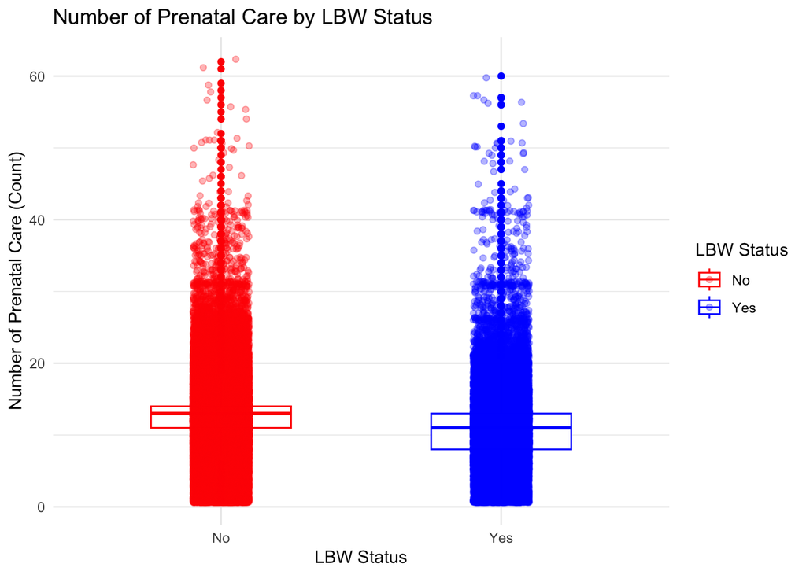

```r
## clean data, make numeric
data_clean$PNC_VST <- as.numeric(data_clean$PNC_VST)
## bar plot of Number of Prenatal Care
data_clean %>%
  filter(!is.na(PNC_VST), !is.na(LBW)) %>%
  ggplot(aes(x = factor(LBW, levels = c("0", "1"), labels = c("No", "Yes")), y = PNC_VST, color = factor(LBW, levels = c("0", "1"), labels = c("No", "Yes")))) +
  geom_boxplot(width = 0.5) +
  geom_jitter(width = 0.1, alpha = 0.3) +
  ggtitle("Number of Prenatal Care by LBW Status") +
  xlab("LBW Status") +
  ylab("Number of Prenatal Care (Count)") +
  scale_color_manual(name = "LBW Status", values = c("red", "blue")) +
  theme_minimal()  # Use a built-in theme here
```

```r
ci_data <- data_clean %>%
  filter(!is.na(PNC_VST), !is.na(LBW)) %>%
  group_by(LBW) %>%
  summarize(
    Median_Age = median(PNC_VST),
    IQR_Lower = quantile(PNC_VST, 0.25),
    IQR_Upper = quantile(PNC_VST, 0.75)
  )

print(ci_data)
```

```
# A tibble: 2 × 4
  LBW   Median_Age IQR_Lower IQR_Upper
  <fct>      <dbl>     <dbl>     <dbl>
1 0             13        11        14
2 1             11         8        13
```

### 9.9 Maternal Race

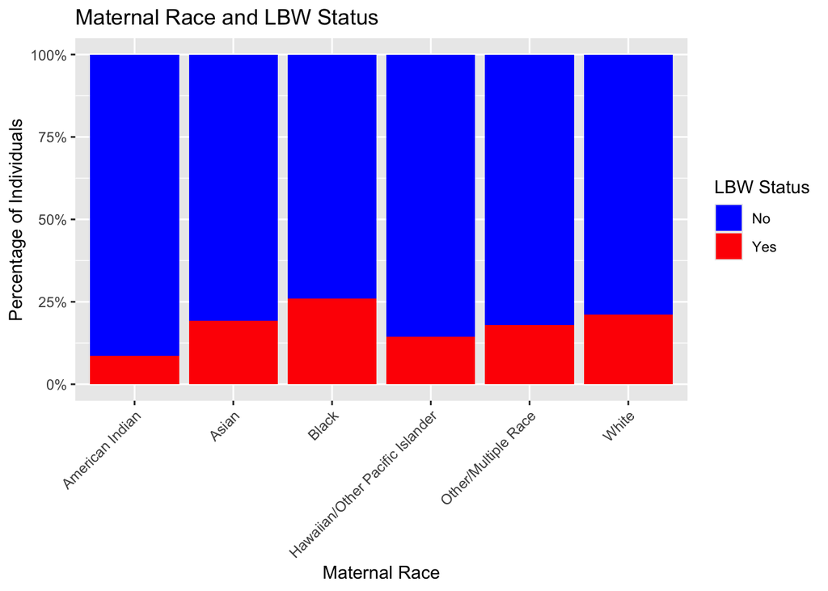

```r
## bar plot of Maternal Race
ggplot(data_clean %>% filter(!is.na(MAT_RACE_PU), !is.na(LBW)), aes(x = MAT_RACE_PU, fill = factor(LBW))) +
  geom_bar(position = "fill") +  # "fill" makes the bars proportional (percentage)
  scale_y_continuous(labels = scales::percent) +
  scale_x_discrete(labels = c("White" = "White", "Black" = "Black", "American Indian" = "American Indian", "Alaska Native" = "Alaska Native", "Asian" = "Asian", "Hawaiian/Other Pacific Islander" = "Hawaiian/Other Pacific Islander", "Other/Multiple Race" = "Other/Multiple Race")) +  # Change 0, 1 to No, Yes on x-axis
  scale_fill_manual(values = c("0" = "blue", "1" = "red"), labels = c("0" = "No", "1" = "Yes")) +  # Change 0, 1 to No, Yes in the legend
  labs(x = "Maternal Race", y = "Percentage of Individuals", fill = "LBW Status",
       title = "Maternal Race and LBW Status") +
  theme(axis.text.x = element_text(angle = 45, hjust = 1))  # Rotate x-axis labels for readability
```

```r
data_clean %>%
  filter(!is.na(MAT_RACE_PU), !is.na(LBW)) %>%
  count(MAT_RACE_PU, LBW)
```

```
# A tibble: 12 × 3
   MAT_RACE_PU                     LBW        n
   <fct>                           <fct>  <int>
 1 American Indian                 0       7942
 2 American Indian                 1        747
 3 Asian                           0      13097
 4 Asian                           1       3107
 5 Black                           0      32192
 6 Black                           1      11340
 7 Hawaiian/Other Pacific Islander 0       1134
 8 Hawaiian/Other Pacific Islander 1        192
 9 Other/Multiple Race             0      21260
10 Other/Multiple Race             1       4626
11 White                           0     110815
12 White                           1      29686
```

American Indian 91.4% do not have LBW. 8.6% have LBW. Asian 80.8% do not have LBW. 19.2% have LBW. Black 73.9% do not have LBW. 26.1% have LBW. Hawaiian/Other Pacific Islander 85.5% do not have LBW. 14.5% have LBW. Other/Multiple Race 82.1% do not have LBW. 17.9% have LBW. White 78.9% do not have LBW. 21.1% have LBW.

The data suggests that the Black racial group has the highest proportion of LBW cases (26.1%), followed by White (21.1%) and Asian (19.2%) individuals. The American Indian and Hawaiian/Other Pacific Islander groups show the lowest rates of LBW. This disparity highlights the potential need for addressing race-related factors contributing to LBW and suggests the importance of tailored interventions for different racial groups.

## 10 Dot plot of Occurrences of LBW for each state

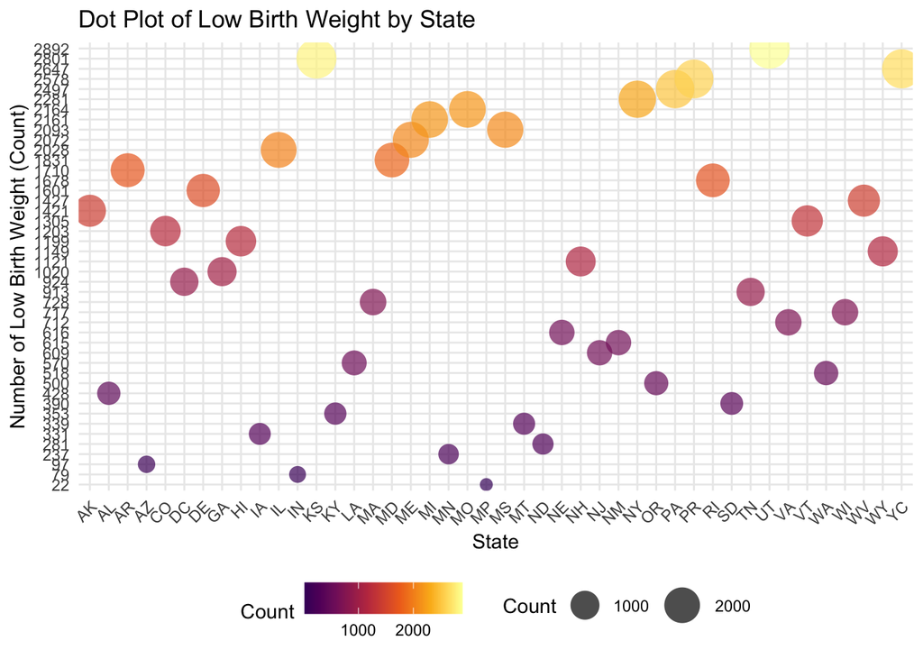

```r
# Summarize the data: Count occurrences of LBW for each state
heatmap_data <- data_clean %>%
  group_by(STATE, LBW) %>%
  summarise(count = n(), .groups = 'drop') %>%
  pivot_wider(names_from = LBW, values_from = count, values_fill = list(count = 0))  # Reshape the data

# Create the dot plot with enhanced color scale
ggplot(heatmap_data, aes(x = STATE, y = factor(`1`), size = `1`, color = `1`)) +  # Use the '1' column for LBW=1
  geom_point(shape = 16, alpha = 0.7) +  # Use dots (size indicates count)
  scale_size_continuous(range = c(3, 10)) +  # Adjust size of dots
  scale_color_viridis_c(option = "inferno", begin = 0.2, end = 1) +  # Use the 'inferno' color palette for better contrast
  labs(title = "Dot Plot of Low Birth Weight by State",
       x = "State", y = "Number of Low Birth Weight (Count)",
       color = "Count", size = "Count") +
  theme_minimal() +
  theme(axis.text.x = element_text(angle = 45, hjust = 1)) +
  theme(legend.position = "bottom")  # Position the legend at the bottom
```

Top 5 Places with Highest LBW Counts Kansas Utah New York City Puerto Rico Pennsylvania

```r
# Set reference categories only for categorical variables
data_clean <- data_clean %>%
  mutate(
    PRE_LB_NAPHSIS = relevel( PRE_LB_NAPHSIS, ref = "0"),
    MAT_ED = relevel(MAT_ED, ref = "Bachelor's, Master's, or higher"),  # Set reference for       MAT_ED
    INCOME8 = relevel(INCOME8, ref = "Low income (0 - $40,000)"),  # Set reference for INCOME8
    MAT_RACE_PU = relevel(MAT_RACE_PU, ref = "White")  # Set reference for MAT_RACE_PU (if you want to control this)
  )
```

### 10.1 Pre-Preg

```r
# Unadjusted logistic regression for LBW with pre-pregnancy folic acid
logit_prepreg_unadjusted <- glm(
  LBW ~ PRE_VIT_RAW,
  data = data_clean,
  family = binomial()
)

# Adjusted logistic regression for LBW with pre-pregnancy folic acid
logit_prepreg_adjusted <- glm(
  LBW ~ PRE_VIT_RAW + MAT_AGE_PU + MOM_BMI + PRE_LB_NAPHSIS + MAT_ED + STATE + INCOME8 + PNC_VST + MAT_RACE_PU,
  data = data_clean,
  family = binomial()
)

# Display unadjusted and adjusted results for pre-pregnancy folic acid
prepreg_unadjusted_results <- summary(logit_prepreg_unadjusted, exponentiate = TRUE, conf.int = TRUE)
prepreg_adjusted_results <- summary(logit_prepreg_adjusted, exponentiate = TRUE, conf.int = TRUE)

print(prepreg_unadjusted_results)
```

```
Call:
glm(formula = LBW ~ PRE_VIT_RAW, family = binomial(), data = data_clean)

Coefficients:
              Estimate Std. Error  z value Pr(>|z|)
(Intercept)  -1.314081   0.007368 -178.340  < 2e-16 ***
PRE_VIT_RAW1  0.054392   0.012128    4.485 7.29e-06 ***
---
Signif. codes:  0 '***' 0.001 '**' 0.01 '*' 0.05 '.' 0.1 ' ' 1

(Dispersion parameter for binomial family taken to be 1)

    Null deviance: 180078  on 172921  degrees of freedom
Residual deviance: 180058  on 172920  degrees of freedom
  (77048 observations deleted due to missingness)
AIC: 180062

Number of Fisher Scoring iterations: 4
```

```r
print(prepreg_adjusted_results)
```

```
Call:
glm(formula = LBW ~ PRE_VIT_RAW + MAT_AGE_PU + MOM_BMI + PRE_LB_NAPHSIS +
    MAT_ED + STATE + INCOME8 + PNC_VST + MAT_RACE_PU, family = binomial(),
    data = data_clean)

Coefficients:
                                            Estimate Std. Error z value
(Intercept)                                -2.184843   0.094395 -23.146
PRE_VIT_RAW1                                0.134830   0.015532   8.681
MAT_AGE_PU                                  0.036719   0.001585  23.173
MOM_BMI                                     0.003104   0.001067   2.908
PRE_LB_NAPHSIS1                            -0.438291   0.017520 -25.016
PRE_LB_NAPHSIS2                            -0.449601   0.019979 -22.503
MAT_ED<= 12th grade, no diploma             0.364458   0.033588  10.851
MAT_EDHigh school graduate / GED            0.333926   0.024186  13.806
MAT_EDSome college, no degree               0.265249   0.020278  13.081
STATEAR                                     1.782119   0.086810  20.529
STATEAZ                                    -0.454712   0.169925  -2.676
STATECO                                     0.737502   0.084082   8.771
STATEDC                                     1.558610   0.094474  16.498
STATEDE                                     1.319873   0.084204  15.675
STATEGA                                     1.232678   0.092969  13.259
STATEIA                                    -0.015534   0.109172  -0.142
STATEIL                                     1.494443   0.082527  18.108
STATEIN                                     0.331745   0.159502   2.080
STATEKS                                     2.276395   0.081549  27.914
STATEKY                                     0.051325   0.105413   0.487
STATELA                                     0.271753   0.095738   2.838
STATEMA                                    -0.173367   0.089341  -1.941
STATEMD                                     1.885614   0.084108  22.419
STATEME                                     2.178068   0.082288  26.469
STATEMI                                     1.104814   0.081512  13.554
STATEMN                                    -0.113131   0.111134  -1.018
STATEMO                                     1.578770   0.082545  19.126
STATEMP                                    -0.080495   0.410965  -0.196
STATEMS                                     2.291607   0.086262  26.566
STATEMT                                    -0.066681   0.103487  -0.644
STATEND                                     0.032782   0.111734   0.293
STATENE                                    -0.126068   0.096077  -1.312
STATENH                                     2.202729   0.087008  25.316
```

[output cut: 78 more lines]

```
MAT_RACE_PUAsian                            < 2e-16 ***
MAT_RACE_PUBlack                            < 2e-16 ***
MAT_RACE_PUHawaiian/Other Pacific Islander 0.137380
MAT_RACE_PUOther/Multiple Race             0.019080 *
---
Signif. codes:  0 '***' 0.001 '**' 0.01 '*' 0.05 '.' 0.1 ' ' 1

(Dispersion parameter for binomial family taken to be 1)

    Null deviance: 143239  on 140307  degrees of freedom
Residual deviance: 120790  on 140251  degrees of freedom
  (109662 observations deleted due to missingness)
AIC: 120904

Number of Fisher Scoring iterations: 5
```

```r
# Extracting Odds Ratios (ORs) and Confidence Intervals (CIs) for the unadjusted model
prepreg_unadjusted_or <- exp(prepreg_unadjusted_results$coefficients[, "Estimate"])
prepreg_unadjusted_se <- prepreg_unadjusted_results$coefficients[, "Std. Error"]
prepreg_unadjusted_ci <- exp(confint.default(logit_prepreg_unadjusted))

# Extracting Odds Ratios (ORs) and Confidence Intervals (CIs) for the adjusted model
prepreg_adjusted_or <- exp(prepreg_adjusted_results$coefficients[, "Estimate"])
prepreg_adjusted_se <- prepreg_adjusted_results$coefficients[, "Std. Error"]
prepreg_adjusted_ci <- exp(confint.default(logit_prepreg_adjusted))

# Combine ORs and CIs into data frames
prepreg_unadjusted_df <- data.frame(
  OR = prepreg_unadjusted_or,
  CI_lower = prepreg_unadjusted_ci[, 1],
  CI_upper = prepreg_unadjusted_ci[, 2]
)

prepreg_adjusted_df <- data.frame(
  OR = prepreg_adjusted_or,
  CI_lower = prepreg_adjusted_ci[, 1],
  CI_upper = prepreg_adjusted_ci[, 2]
)

# Print results
print(prepreg_unadjusted_df)
```

```
                    OR  CI_lower  CI_upper
(Intercept)  0.2687213 0.2648683 0.2726302
PRE_VIT_RAW1 1.0558990 1.0310962 1.0812983
```

```r
print(prepreg_adjusted_df)
```

```
                                                   OR   CI_lower   CI_upper
(Intercept)                                 0.1124954 0.09349452  0.1353579
PRE_VIT_RAW1                                1.1443421 1.11003093  1.1797138
MAT_AGE_PU                                  1.0374012 1.03418447  1.0406280
MOM_BMI                                     1.0031084 1.00101250  1.0052087
PRE_LB_NAPHSIS1                             0.6451379 0.62336024  0.6676764
PRE_LB_NAPHSIS2                             0.6378828 0.61338679  0.6633572
MAT_ED<= 12th grade, no diploma             1.4397337 1.34800593  1.5377033
MAT_EDHigh school graduate / GED            1.3964404 1.33178769  1.4642318
MAT_EDSome college, no degree               1.3037556 1.25295525  1.3566157
STATEAR                                     5.9424325 5.01269542  7.0446139
STATEAZ                                     0.6346308 0.45486281  0.8854454
STATECO                                     2.0907073 1.77305737  2.4652655
STATEDC                                     4.7522100 3.94893108  5.7188892
STATEDE                                     3.7429471 3.17350469  4.4145683
STATEGA                                     3.4304040 2.85897056  4.1160521
STATEIA                                     0.9845857 0.79492536  1.2194968
STATEIL                                     4.4568528 3.79123623  5.2393298
STATEIN                                     1.3933981 1.01931232  1.9047728
STATEKS                                     9.7415024 8.30254461 11.4298535
STATEKY                                     1.0526654 0.85617581  1.2942487
STATELA                                     1.3122629 1.08774789  1.5831185
STATEMA                                     0.8408291 0.70576598  1.0017393
STATEMD                                     6.5903991 5.58879940  7.7715010
STATEME                                     8.8292311 7.51413700 10.3744876
STATEMI                                     3.0186616 2.57294841  3.5415860
STATEMN                                     0.8930333 0.71824071  1.1103638
STATEMO                                     4.8489882 4.12466818  5.7005037
STATEMP                                     0.9226598 0.41231322  2.0646951
STATEMS                                     9.8908160 8.35229662 11.7127355
STATEMT                                     0.9354937 0.76375278  1.1458530
STATEND                                     1.0333249 0.83009699  1.2863080
STATENE                                     0.8815547 0.73024405  1.0642178
STATENH                                     9.0496742 7.63082153 10.7323442
STATENJ                                     0.9183293 0.76049099  1.1089266
STATENM                                     0.9163742 0.75970660  1.1053499
STATENY                                     9.5934286 8.15186660 11.2899139
STATEOR                                     0.8184794 0.67478777  0.9927691
STATEPA                                     5.8796518 5.00838758  6.9024821
STATEPR                                    10.0997374 8.58182769 11.8861272
STATERI                                     6.7381133 5.68328104  7.9887252
STATESD                                     0.8088317 0.65867549  0.9932186
STATETN                                    10.2074001 8.42492224 12.3670004
STATEUT                                     6.4260558 5.49118865  7.5200828
STATEVA                                     1.4066069 1.17485412  1.6840754
STATEWA                                     0.7453778 0.61454428  0.9040652
STATEWI                                     1.1366539 0.95043042  1.3593653
STATEWV                                     9.2187674 7.71870905 11.0103480
STATEWY                                     6.6879679 5.62144806  7.9568315
STATEYC                                     4.0621465 3.45870748  4.7708672
INCOME8High income ($85,001 or more)        0.7213821 0.68881609  0.7554878
INCOME8Middle ($40,001 - $85,000)           0.8075703 0.77584247  0.8405956
PNC_VST                                     0.8875870 0.88407796  0.8911099
MAT_RACE_PUAmerican Indian                  0.6433131 0.56730218  0.7295084
MAT_RACE_PUAsian                            1.4603693 1.36715760  1.5599362
MAT_RACE_PUBlack                            1.4731501 1.41156299  1.5374243
MAT_RACE_PUHawaiian/Other Pacific Islander  0.7647852 0.53690067  1.0893940
MAT_RACE_PUOther/Multiple Race              1.0727278 1.01156746  1.1375860
```

Pre-pregnancy folic acid intake is associated with higher odds of LBW (OR = 1.056, p-value = 7.29e-06, 95% CI: [1.031, 1.081]).

Adjusting for confounders, pre-pregnancy folic acid intake is associated with higher odds of LBW (OR = 1.144, p-value = < 2e-16, 95% CI: [1.110, 1.180]).

### 10.2 During Preg

```r
# Unadjusted logistic regression for LBW with during-pregnancy folic acid
logit_duringpreg_unadjusted <- glm(
  LBW ~ VPP_VIT_RAW,
  data = data_clean,
  family = binomial()
)

# Adjusted logistic regression for LBW with during-pregnancy folic acid
logit_duringpreg_adjusted <- glm(
  LBW ~ VPP_VIT_RAW + MAT_AGE_PU + MOM_BMI + PRE_LB_NAPHSIS + MAT_ED + STATE + INCOME8 + PNC_VST + MAT_RACE_PU,
  data = data_clean,
  family = binomial()
)

# Display unadjusted and adjusted results for during-pregnancy folic acid
duringpreg_unadjusted_results <- summary(logit_duringpreg_unadjusted, exponentiate = TRUE, conf.int = TRUE)
duringpreg_adjusted_results <- summary(logit_duringpreg_adjusted, exponentiate = TRUE, conf.int = TRUE)

print(duringpreg_unadjusted_results)
```

```
Call:
glm(formula = LBW ~ VPP_VIT_RAW, family = binomial(), data = data_clean)

Coefficients:
              Estimate Std. Error z value Pr(>|z|)
(Intercept)  -1.289061   0.007822 -164.79  < 2e-16 ***
VPP_VIT_RAW1 -0.081818   0.010599   -7.72 1.17e-14 ***
---
Signif. codes:  0 '***' 0.001 '**' 0.01 '*' 0.05 '.' 0.1 ' ' 1

(Dispersion parameter for binomial family taken to be 1)

    Null deviance: 222773  on 217578  degrees of freedom
Residual deviance: 222714  on 217577  degrees of freedom
  (32391 observations deleted due to missingness)
AIC: 222718

Number of Fisher Scoring iterations: 4
```

```r
print(duringpreg_adjusted_results)
```

```
Call:
glm(formula = LBW ~ VPP_VIT_RAW + MAT_AGE_PU + MOM_BMI + PRE_LB_NAPHSIS +
    MAT_ED + STATE + INCOME8 + PNC_VST + MAT_RACE_PU, family = binomial(),
    data = data_clean)

Coefficients:
                                             Estimate Std. Error z value
(Intercept)                                -2.0502920  0.0795872 -25.762
VPP_VIT_RAW1                               -0.0404300  0.0131530  -3.074
MAT_AGE_PU                                  0.0372128  0.0014233  26.145
MOM_BMI                                     0.0009019  0.0009647   0.935
PRE_LB_NAPHSIS1                            -0.4364337  0.0158473 -27.540
PRE_LB_NAPHSIS2                            -0.4674789  0.0180348 -25.921
MAT_ED<= 12th grade, no diploma             0.3230560  0.0292431  11.047
MAT_EDHigh school graduate / GED            0.3042536  0.0216124  14.078
MAT_EDSome college, no degree               0.2280738  0.0186694  12.216
STATEAR                                     1.7249889  0.0713687  24.170
STATEAZ                                    -0.2877186  0.1367168  -2.104
STATECO                                     0.6113754  0.0704209   8.682
STATEDC                                     1.5247445  0.0805698  18.925
STATEDE                                     1.2780424  0.0699303  18.276
STATEGA                                     1.2520713  0.0751488  16.661
STATEIA                                    -0.0978861  0.0914388  -1.071
STATEIL                                     1.4297408  0.0680872  20.999
STATEIN                                     0.1768309  0.1453115   1.217
STATEKS                                     2.2347607  0.0670807  33.315
STATEKY                                     0.0399962  0.0899621   0.445
STATELA                                     0.2248861  0.0809273   2.779
STATEMA                                    -0.2164029  0.0749523  -2.887
STATEMD                                     1.7501006  0.0700324  24.990
STATEME                                     2.1100175  0.0682377  30.922
STATEMI                                     1.0442665  0.0670591  15.572
STATEMN                                    -0.1910784  0.0991522  -1.927
STATEMO                                     1.5115553  0.0680361  22.217
STATEMP                                     0.2357147  0.3346011   0.704
STATEMS                                     2.2682398  0.0703985  32.220
STATEMT                                    -0.1525614  0.0893948  -1.707
STATEND                                    -0.1464080  0.0993348  -1.474
STATENE                                    -0.1008937  0.0782717  -1.289
STATENH                                     2.1303596  0.0736822  28.913
```

[output cut: 78 more lines]

```
MAT_RACE_PUAsian                            < 2e-16 ***
MAT_RACE_PUBlack                            < 2e-16 ***
MAT_RACE_PUHawaiian/Other Pacific Islander  0.07233 .
MAT_RACE_PUOther/Multiple Race              0.08854 .
---
Signif. codes:  0 '***' 0.001 '**' 0.01 '*' 0.05 '.' 0.1 ' ' 1

(Dispersion parameter for binomial family taken to be 1)

    Null deviance: 175389  on 174316  degrees of freedom
Residual deviance: 148235  on 174260  degrees of freedom
  (75653 observations deleted due to missingness)
AIC: 148349

Number of Fisher Scoring iterations: 5
```

```r
# Extracting Odds Ratios (ORs) and Confidence Intervals (CIs) for the unadjusted model
duringpreg_unadjusted_or <- exp(duringpreg_unadjusted_results$coefficients[, "Estimate"])
duringpreg_unadjusted_se <- duringpreg_unadjusted_results$coefficients[, "Std. Error"]
duringpreg_unadjusted_ci <- exp(confint.default(logit_duringpreg_unadjusted))

# Extracting Odds Ratios (ORs) and Confidence Intervals (CIs) for the adjusted model
duringpreg_adjusted_or <- exp(duringpreg_adjusted_results$coefficients[, "Estimate"])
duringpreg_adjusted_se <- duringpreg_adjusted_results$coefficients[, "Std. Error"]
duringpreg_adjusted_ci <- exp(confint.default(logit_duringpreg_adjusted))

# Combine ORs and CIs into data frames
duringpreg_unadjusted_df <- data.frame(
  OR = duringpreg_unadjusted_or,
  CI_lower = duringpreg_unadjusted_ci[, 1],
  CI_upper = duringpreg_unadjusted_ci[, 2]
)

duringpreg_adjusted_df <- data.frame(
  OR = duringpreg_adjusted_or,
  CI_lower = duringpreg_adjusted_ci[, 1],
  CI_upper = duringpreg_adjusted_ci[, 2]
)

# Print results
print(duringpreg_unadjusted_df)
```

```
                    OR  CI_lower  CI_upper
(Intercept)  0.2755294 0.2713373 0.2797862
VPP_VIT_RAW1 0.9214394 0.9024954 0.9407810
```

```r
print(duringpreg_adjusted_df)
```

```
                                                  OR  CI_lower   CI_upper
(Intercept)                                0.1286973 0.1101095  0.1504230
VPP_VIT_RAW1                               0.9603764 0.9359348  0.9854562
MAT_AGE_PU                                 1.0379139 1.0350225  1.0408134
MOM_BMI                                    1.0009023 0.9990115  1.0027966
PRE_LB_NAPHSIS1                            0.6463373 0.6265705  0.6667277
PRE_LB_NAPHSIS2                            0.6265799 0.6048187  0.6491241
MAT_ED<= 12th grade, no diploma            1.3813427 1.3043967  1.4628277
MAT_EDHigh school graduate / GED           1.3556128 1.2993888  1.4142695
MAT_EDSome college, no degree              1.2561781 1.2110437  1.3029946
STATEAR                                    5.6124586 4.8798219  6.4550906
STATEAZ                                    0.7499726 0.5736828  0.9804353
STATECO                                    1.8429645 1.6053680  2.1157255
STATEDC                                    4.5939696 3.9228976  5.3798389
STATEDE                                    3.5896058 3.1298387  4.1169119
STATEGA                                    3.4975799 3.0185675  4.0526061
STATEIA                                    0.9067522 0.7579766  1.0847294
STATEIL                                    4.1776164 3.6557175  4.7740228
STATEIN                                    1.1934293 0.8976506  1.5866679
STATEKS                                    9.3442454 8.1930399 10.6572070
STATEKY                                    1.0408069 0.8725579  1.2414980
STATELA                                    1.2521801 1.0685168  1.4674127
STATEMA                                    0.8054107 0.6953732  0.9328609
STATEMD                                    5.7551815 5.0170374  6.6019269
STATEME                                    8.2483856 7.2158066  9.4287262
STATEMI                                    2.8413137 2.4913708  3.2404102
STATEMN                                    0.8260678 0.6801696  1.0032616
STATEMO                                    4.5337767 3.9677813  5.1805101
STATEMP                                    1.2658131 0.6569867  2.4388357
STATEMS                                    9.6623781 8.4170664 11.0919345
STATEMT                                    0.8585062 0.7205273  1.0229076
STATEND                                    0.8638052 0.7109873  1.0494694
STATENE                                    0.9040291 0.7754565  1.0539194
STATENH                                    8.4178936 7.2859305  9.7257218
STATENJ                                    0.8386616 0.7153593  0.9832168
STATENM                                    0.8702231 0.7453162  1.0160631
STATENY                                    9.1364990 7.9767492 10.4648662
STATEOR                                    0.7628313 0.6486440  0.8971201
STATEPA                                    5.5527583 4.8623313  6.3412224
STATEPR                                    9.9407813 8.6812848 11.3830077
STATERI                                    6.2412537 5.4132651  7.1958878
STATESD                                    0.7501250 0.6311445  0.8915353
STATETN                                    9.3116330 7.9270475 10.9380584
STATEUT                                    5.7235906 5.0300459  6.5127616
STATEVA                                    1.3611630 1.1712361  1.5818883
STATEWA                                    0.6684121 0.5678969  0.7867181
STATEWI                                    1.0659004 0.9166283  1.2394814
STATEWV                                    8.4778285 7.3210855  9.8173386
STATEWY                                    6.2227447 5.3852259  7.1905156
STATEYC                                    3.8935253 3.4103107  4.4452076
INCOME8High income ($85,001 or more)       0.7734472 0.7416716  0.8065841
INCOME8Middle ($40,001 - $85,000)          0.8474593 0.8176821  0.8783209
PNC_VST                                    0.8875581 0.8843813  0.8907463
MAT_RACE_PUAmerican Indian                 0.7031833 0.6303815  0.7843929
MAT_RACE_PUAsian                           1.4319896 1.3514150  1.5173682
MAT_RACE_PUBlack                           1.4769885 1.4220686  1.5340294
MAT_RACE_PUHawaiian/Other Pacific Islander 0.7622025 0.5668243  1.0249256
MAT_RACE_PUOther/Multiple Race             1.0456851 0.9932866  1.1008478
```

## 11 Forrest Plot Logistic Regression Results

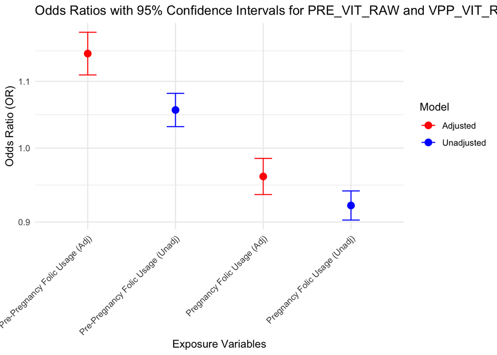

```r
# Combine unadjusted and adjusted results for PRE_VIT_RAW
prepreg_df <- data.frame(
  Exposure = c("Pre-Pregnancy Folic Usage (Unadj)", "Pre-Pregnancy Folic Usage (Adj)"),
  OR = c(prepreg_unadjusted_or["PRE_VIT_RAW1"], prepreg_adjusted_or["PRE_VIT_RAW1"]),
  CI_lower = c(prepreg_unadjusted_ci["PRE_VIT_RAW1", 1], prepreg_adjusted_ci["PRE_VIT_RAW1", 1]),
  CI_upper = c(prepreg_unadjusted_ci["PRE_VIT_RAW1", 2], prepreg_adjusted_ci["PRE_VIT_RAW1", 2]),
  Model = c("Unadjusted", "Adjusted")
)

# Combine unadjusted and adjusted results for VPP_VIT_RAW
duringpreg_df <- data.frame(
  Exposure = c("Pregnancy Folic Usage (Unadj)", "Pregnancy Folic Usage (Adj)"),
  OR = c(duringpreg_unadjusted_or["VPP_VIT_RAW1"], duringpreg_adjusted_or["VPP_VIT_RAW1"]),
  CI_lower = c(duringpreg_unadjusted_ci["VPP_VIT_RAW1", 1], duringpreg_adjusted_ci["VPP_VIT_RAW1", 1]),
  CI_upper = c(duringpreg_unadjusted_ci["VPP_VIT_RAW1", 2], duringpreg_adjusted_ci["VPP_VIT_RAW1", 2]),
  Model = c("Unadjusted", "Adjusted")
)

# Combine both data frames into one
combined_df <- bind_rows(prepreg_df, duringpreg_df)

# Plot the Odds Ratios with Confidence Intervals
ggplot(combined_df, aes(x = Exposure, y = OR, color = Model, group = Exposure)) +
  geom_point(size = 3) +
  geom_errorbar(aes(ymin = CI_lower, ymax = CI_upper), width = 0.2) +
  scale_y_log10() +  # Log scale for better visualization
  labs(
    x = "Exposure Variables",
    y = "Odds Ratio (OR)",
    title = "Odds Ratios with 95% Confidence Intervals for PRE_VIT_RAW and VPP_VIT_RAW"
  ) +
  theme_minimal() +
  theme(axis.text.x = element_text(angle = 45, hjust = 1)) +
  scale_color_manual(values = c("Unadjusted" = "blue", "Adjusted" = "red"))
```

## 12 Conclusion

This study highlights several critical factors that influence LBW outcomes, with a particular focus on maternal folic acid intake, maternal education, socioeconomic status, and race. The analysis suggests that both pre-pregnancy and pregnancy folic acid intake are significantly associated with LBW, although the association with pregnancy folic acid intake appears to be protective (OR = 0.96), while pre-pregnancy intake is linked to a slight increase in the odds of LBW (OR = 1.14). These findings suggest that the timing of folic acid supplementation may play a role in birth weight outcomes, with pregnancy supplementation potentially offering more favorable outcomes.

Socioeconomic factors, including income and maternal education, are also significant contributors to LBW risk. Higher maternal education and income are associated with lower rates of LBW, emphasizing the importance of addressing socioeconomic disparities in maternal health. The findings further indicate that racial disparities exist, with Black women having the highest proportion of LBW cases (26.1%), followed by White and Asian women, underscoring the need for targeted interventions within different racial groups.

Maternal age, parity, and prenatal care visits were found to influence birth weight outcomes as well. First-time pregnancies were associated with the highest LBW risk, suggesting that a history of prior pregnancies may improve maternal health outcomes. Additionally, more frequent prenatal care visits were linked to better birth weight outcomes, underscoring the importance of adequate prenatal care in reducing LBW risk.

This study also identifies geographical disparities in LBW, with certain states and regions, such as Kansas and Puerto Rico, showing higher LBW counts, potentially reflecting regional variations in healthcare access and maternal health services.

In conclusion, improving maternal health outcomes and reducing LBW rates require a multifaceted approach that includes addressing nutritional, socioeconomic, healthcare access, and racial disparities. The role of folic acid intake, particularly during pregnancy, should be emphasized in maternal health guidelines, and public health interventions should focus on increasing access to prenatal care, promoting education, and addressing the underlying socioeconomic and racial factors that contribute to LBW.

References

1. Organization WH. International statistical classification of diseases and related health problems, tenth revision, 2nd ed. World Health Organization; 2004.
2. Jańczewska, I., Wierzba, J., Jańczewska, A., Szczurek-Gierczak, M., & Domżalska-Popadiuk, I. (2023). Prematurity and Low Birth Weight and Their Impact on Childhood Growth Patterns and the Risk of Long-Term Cardiovascular Sequelae. *Children*, *10*(10), Article 10. https://doi.org/10.3390/children10101599
3. Fu, M., Song, W., Yu, G., Yu, Y., & Yang, Q. (2023). Risk factors for length of NICU stay of newborns: A systematic review. *Frontiers in Pediatrics*, *11*, 1121406. https://doi.org/10.3389/fped.2023.1121406
4. Houk, V. N., Oakley, G. P., Erickson, J. D., Mulinare, J., & James, L. M. (n.d.). *Recommendations for the use of folic acid to reduce the number of cases of spina bifida and other neural tube defects*. Retrieved November 12, 2024, from https://stacks.cdc.gov/view/cdc/7079
5. Scholl, T. O., & Johnson, W. G. (2000). Folic acid: Influence on the outcome of pregnancy1234. *The American Journal of Clinical Nutrition*, *71*(5), 1295S-1303S. https://doi.org/10.1093/ajcn/71.5.1295s